# PCA

## PCA implementation

```python
import numpy as np
import pandas as pd
import matplotlib.pyplot as plt
from mpl_toolkits.mplot3d import Axes3D
import seaborn as sns
from sklearn.datasets import make_moons
import plotly.express as px
import plotly.offline as pyo
import plotly.figure_factory as ff
import plotly.graph_objects as go

from sklearn.preprocessing import StandardScaler
from sklearn.datasets import load_iris

np.random.seed(41)
sns.set(style="darkgrid")
```

**The dataset consists of 150 samples from three species of iris flowers: Setosa, Versicolor, and Virginica.**

**The plot visualizes the Iris dataset using three features: sepal length, petal length, and petal width.**

```python
raw_data = load_iris()
data = raw_data['data']
target = raw_data['target']
feature_names = list(raw_data['feature_names'])
feature_names = [name.replace(' ', '_')[:-5] for name in feature_names]
df = pd.DataFrame(data=np.c_[data, target], columns=feature_names + ['class'])
df['class'] = df['class'].map({0.0: 'setosa', 1.0: 'versicolor', 2.0: 'virginica'})
df.head()
```

|  | sepal_length | sepal_width | petal_length | petal_width | class |
| --- | --- | --- | --- | --- | --- |
| 0 | 5.1 | 3.5 | 1.4 | 0.2 | setosa |
| 1 | 4.9 | 3.0 | 1.4 | 0.2 | setosa |
| 2 | 4.7 | 3.2 | 1.3 | 0.2 | setosa |
| 3 | 4.6 | 3.1 | 1.5 | 0.2 | setosa |
| 4 | 5.0 | 3.6 | 1.4 | 0.2 | setosa |

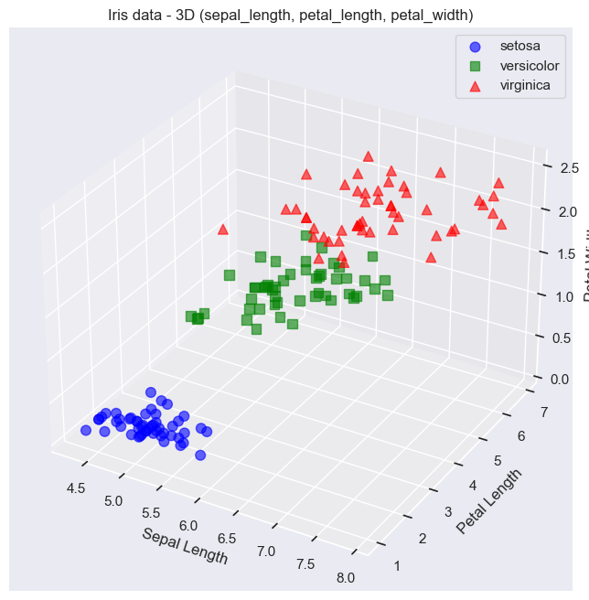

```python
fig = plt.figure(figsize=(10, 8))
ax = fig.add_subplot(111, projection='3d')

colors = {'setosa': 'blue', 'versicolor': 'green', 'virginica': 'red'}
markers = {'setosa': 'o', 'versicolor': 's', 'virginica': '^'}

for class_name, group in df.groupby('class'):
    ax.scatter(group['sepal_length'], group['petal_length'], group['petal_width'],
               color=colors[class_name], marker=markers[class_name],
               label=class_name, s=60, alpha=0.6)

ax.set_xlabel('Sepal Length')
ax.set_ylabel('Petal Length')
ax.set_zlabel('Petal Width')
ax.set_title('Iris data - 3D (sepal_length, petal_length, petal_width)')

ax.legend()
plt.show()
```

**The features sepal_length, petal_length, and petal_width are selected for PCA analysis. Before performing PCA, the features are standardized using StandardScaler() to ensure that they have a mean of 0 and standard deviation of 1.**

**The matrix measures the relationship between the variables (sepal length, petal length, and petal width) after standardization.**

```python
X = df.iloc[:, [0, 2, 3]]
y = df.iloc[:, -1]

scaler = StandardScaler()
scaler.fit(X)
X_std = scaler.transform(X)

cov_mat = np.cov(X_std, rowvar=False)
cov_mat
```

```
array([[1.00671141, 0.87760447, 0.82343066],
       [0.87760447, 1.00671141, 0.96932762],
       [0.82343066, 0.96932762, 1.00671141]])
```

**Using np.linalg.eig(), the eigenvalues and eigenvectors of the covariance matrix are calculated. These values are essential for PCA:**

- **Eigenvalues tell how much variance each principal component explains.**
- **Eigenvectors indicate the directions of the principal components in feature space.**

```python
eig_vals, eig_vecs = np.linalg.eig(cov_mat)

print(f'Eigenvalues:\n{eig_vals}\n')
print(f'Eigenvectors:\n{eig_vecs}')

eig_pairs = [(np.abs(eig_vals[i]), eig_vecs[:, i]) for i in range(len(eig_vals))]
eig_pairs.sort(reverse=True)
eig_pairs
```

```
Eigenvalues:
[2.78833033 0.20075012 0.03105378]

Eigenvectors:
[[ 0.55964149  0.81270446  0.16221241]
 [ 0.59148855 -0.2546058  -0.76506024]
 [ 0.58046765 -0.52410624  0.62319335]]
```

```
[(2.7883303296752926, array([0.55964149, 0.59148855, 0.58046765])),
 (0.20075011806343787, array([ 0.81270446, -0.2546058 , -0.52410624])),
 (0.031053780449189813, array([ 0.16221241, -0.76506024,  0.62319335]))]
```

**The explained variance ratio is computed by dividing each eigenvalue by the total sum of eigenvalues. This metric shows how much variance each principal component captures.**

```python
total = sum(eig_vals)
explained_variance_ratio = [(i / total) for i in sorted(eig_vals, reverse=True)]
explained_variance_ratio
```

```
[0.9232471536035967, 0.06647059464767163, 0.010282251748731736]
```

```python
cumulative_explained_variance = np.cumsum(explained_variance_ratio)
cumulative_explained_variance
```

```
array([0.92324715, 0.98971775, 1.        ])
```

```python
results = pd.DataFrame(data={'explained_variance_ratio': explained_variance_ratio})
results['cumulative'] = results['explained_variance_ratio'].cumsum()
results['component'] = results.index
results
```

|  | explained_variance_ratio | cumulative | component |
| --- | --- | --- | --- |
| 0 | 0.923247 | 0.923247 | 0 |
| 1 | 0.066471 | 0.989718 | 1 |
| 2 | 0.010282 | 1.000000 | 2 |

**A bar chart and a cumulative line chart visualizing the explained variance ratio for the first three principal components.**

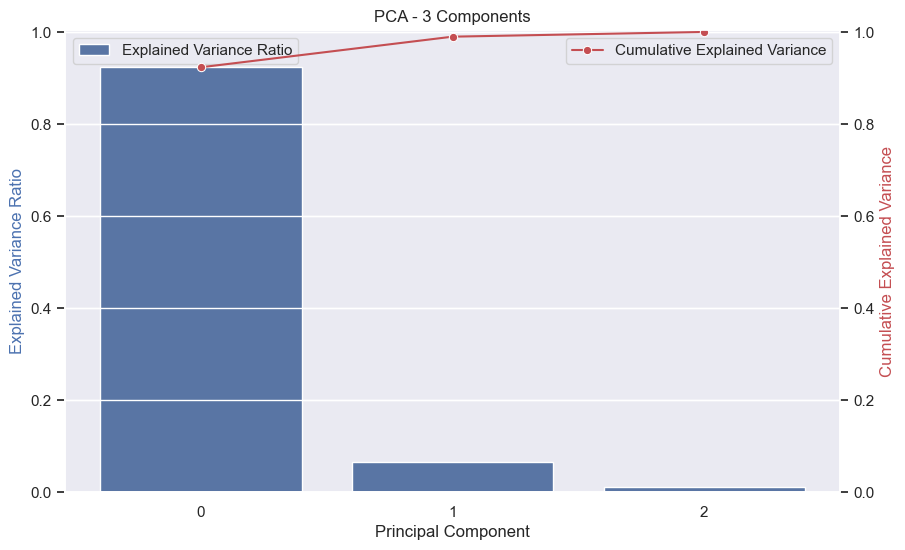

```python
fig, ax1 = plt.subplots(figsize=(10, 6))

sns.barplot(x='component', y='explained_variance_ratio', data=results, ax=ax1, color="b", label="Explained Variance Ratio")

ax1.set_ylabel('Explained Variance Ratio', color='b')
ax1.set_xlabel('Principal Component')
ax1.set_title('PCA - 3 Components')

ax2 = ax1.twinx()

sns.lineplot(x='component', y='cumulative', data=results, ax=ax2, color="r", marker="o", label="Cumulative Explained Variance")

ax2.set_ylabel('Cumulative Explained Variance', color='r')

y_min = min(ax1.get_ylim()[0], ax2.get_ylim()[0])
y_max = max(ax1.get_ylim()[1], ax2.get_ylim()[1])

ax1.set_ylim(y_min, y_max)
ax2.set_ylim(y_min, y_max)

ax1.legend(loc='upper left')
ax2.legend(loc='upper right')

plt.show()
```

**A 2-component PCA is performed by selecting the two eigenvectors that correspond to the largest eigenvalues. These vectors are stacked to form a matrix W, which is then used to project the original data (X_std) into a 2D space:**

```python
W = np.hstack((eig_pairs[0][1].reshape(3, 1), eig_pairs[1][1].reshape(3, 1)))
W
```

```
array([[ 0.55964149,  0.81270446],
       [ 0.59148855, -0.2546058 ],
       [ 0.58046765, -0.52410624]])
```

```python
X_pca = X_std.dot(W)
pca_df = pd.DataFrame(data=X_pca, columns=['pca_1', 'pca_2'])
pca_df['class'] = df['class']
pca_df['pca_2'] = - pca_df['pca_2']
pca_df
```

|  | pca_1 | pca_2 | class |
| --- | --- | --- | --- |
| 0 | -2.060360 | -0.298674 | setosa |
| 1 | -2.195981 | -0.101727 | setosa |
| 2 | -2.365221 | 0.080749 | setosa |
| 3 | -2.365794 | 0.208165 | setosa |
| 4 | -2.128171 | -0.200201 | setosa |
| ... | ... | ... | ... |
| 145 | 1.906692 | 0.124424 | virginica |
| 146 | 1.262579 | 0.213420 | virginica |
| 147 | 1.541846 | 0.114404 | virginica |
| 148 | 1.634876 | 0.645735 | virginica |
| 149 | 0.948548 | 0.552796 | virginica |

150 rows × 3 columns

**The resulting 2D data is stored in pca_df and visualized using a 2D scatter plot. The points are colored by species, showing how well the PCA separates the classes.**

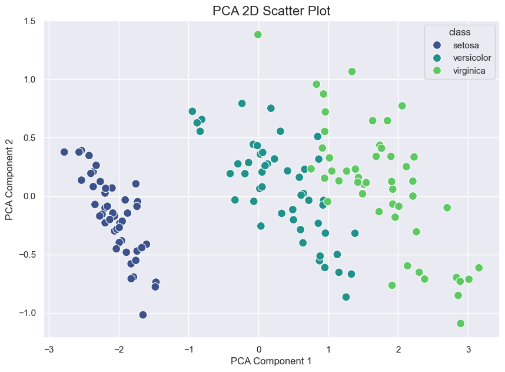

```python
plt.figure(figsize=(10, 7))

sns.scatterplot(x='pca_1', y='pca_2', hue='class', data=pca_df, palette='viridis', s=100, edgecolor='w')

plt.title('PCA 2D Scatter Plot', fontsize=16)
plt.xlabel('PCA Component 1', fontsize=12)
plt.ylabel('PCA Component 2', fontsize=12)

plt.show()
```

## PCA class from sklearn dataset

```python
from sklearn.decomposition import PCA

pca = PCA(n_components=2)
X_pca = pca.fit_transform(X_std)

pca_df = pd.DataFrame(data=X_pca, columns=['pca_1', 'pca_2'])
pca_df['class'] = df['class']
pca_df
```

|  | pca_1 | pca_2 | class |
| --- | --- | --- | --- |
| 0 | -2.060360 | -0.298674 | setosa |
| 1 | -2.195981 | -0.101727 | setosa |
| 2 | -2.365221 | 0.080749 | setosa |
| 3 | -2.365794 | 0.208165 | setosa |
| 4 | -2.128171 | -0.200201 | setosa |
| ... | ... | ... | ... |
| 145 | 1.906692 | 0.124424 | virginica |
| 146 | 1.262579 | 0.213420 | virginica |
| 147 | 1.541846 | 0.114404 | virginica |
| 148 | 1.634876 | 0.645735 | virginica |
| 149 | 0.948548 | 0.552796 | virginica |

150 rows × 3 columns

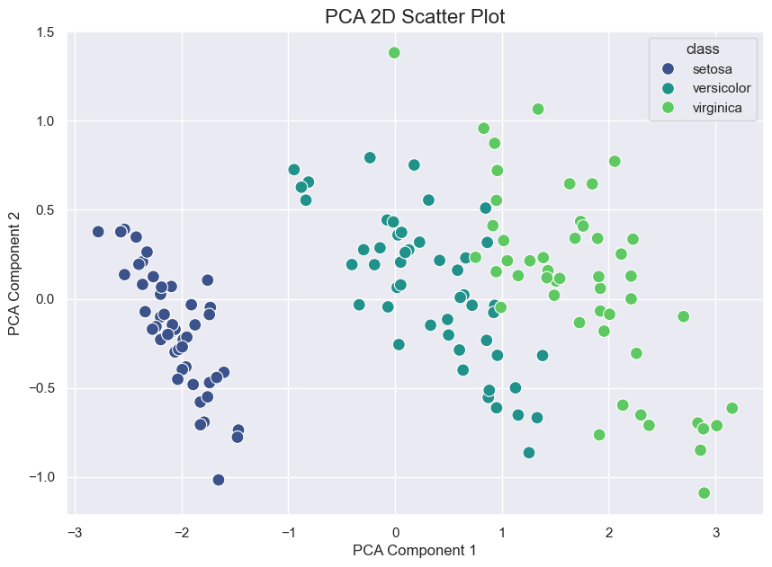

```python
plt.figure(figsize=(10, 7))

sns.scatterplot(x='pca_1', y='pca_2', hue='class', data=pca_df, palette='viridis', s=100, edgecolor='w')

plt.title('PCA 2D Scatter Plot', fontsize=16)
plt.xlabel('PCA Component 1', fontsize=12)
plt.ylabel('PCA Component 2', fontsize=12)

plt.show()
```